## Liquor Sales in Iowa

This dataset contains the spirits purchase information of Iowa Class âEâ liquor licensees by product and date of purchase from January 1, 2012 to current. The dataset can be used to analyze total spirits sales in Iowa of individual products at the store level.

For all of the questions use functionality from the `tidyverse` whenever possible.

1. Download the RMarkdown file with these homework instructions to use as a template for your work. Make sure to replace “Your Name” in the YAML with your name.
2. The code below downloads the data from the Iowa Portal and saves a local copy to your machine. The first time you run this code, make sure you have a good internet connection and enough space on your machine (~50 MB). If the local copy exists, re-knitting the file will load the (binary) file from disk and be much faster.

```r
if (file.exists("alcohol.rds")) {
  data <- readRDS("alcohol.rds")
} else {
  url <- "https://xdaiisu.github.io/ds202materials/data/ames.csv"
  data <- readr::read_csv(url)
  saveRDS(data, file="alcohol.rds")
}
```

```r
suppressMessages(library(tidyverse))
theme_set(theme_light())
```

### Understanding the data

```r
data <- readr::read_csv("Iowa-Liquor-Sales-2018.csv")
head(data)
```

```
## # A tibble: 6 x 24
##   `Invoice/Item N~ Date  `Store Number` `Store Name` Address City
##   <chr>            <chr>          <dbl> <chr>        <chr>   <chr>
## 1 INV-14210900003  09/0~           4617 Lickety Liq~ 2501 H~ Des ~
## 2 INV-14210900004  09/0~           4617 Lickety Liq~ 2501 H~ Des ~
## 3 INV-14210900005  09/0~           4617 Lickety Liq~ 2501 H~ Des ~
## 4 INV-14210900006  09/0~           4617 Lickety Liq~ 2501 H~ Des ~
## 5 INV-14210900007  09/0~           4617 Lickety Liq~ 2501 H~ Des ~
## 6 INV-14214000056  09/0~           4361 Quik Trip #~ 4575 N~ Des ~
## # ... with 18 more variables: `Zip Code` <dbl>, `Store Location` <chr>,
## #   `County Number` <dbl>, County <chr>, Category <dbl>, `Category
## #   Name` <chr>, `Vendor Number` <chr>, `Vendor Name` <chr>, `Item
## #   Number` <dbl>, `Item Description` <chr>, Pack <dbl>, `Bottle Volume
## #   (ml)` <dbl>, `State Bottle Cost` <dbl>, `State Bottle Retail` <dbl>,
## #   `Bottles Sold` <dbl>, `Sale (Dollars)` <dbl>, `Volume Sold
## #   (Liters)` <dbl>, `Volume Sold (Gallons)` <dbl>
```

```r
glimpse(data)
```

```
## Observations: 2,355,558
## Variables: 24
## $ `Invoice/Item Number`   <chr> "INV-14210900003", "INV-14210900004", ...
## $ Date                    <chr> "09/04/2018", "09/04/2018", "09/04/201...
## $ `Store Number`          <dbl> 4617, 4617, 4617, 4617, 4617, 4361, 43...
## $ `Store Name`            <chr> "Lickety Liquor", "Lickety Liquor", "L...
## $ Address                 <chr> "2501 HUBBELL AVE", "2501 HUBBELL AVE"...
## $ City                    <chr> "Des Moines", "Des Moines", "Des Moine...
## $ `Zip Code`              <dbl> 50317, 50317, 50317, 50317, 50317, 503...
## $ `Store Location`        <chr> "2501 HUBBELL AVE\nDes Moines 50317\n(...
## $ `County Number`         <dbl> 77, 77, 77, 77, 77, 77, 77, 77, 77, 77...
## $ County                  <chr> "POLK", "POLK", "POLK", "POLK", "POLK"...
## $ Category                <dbl> 1011400, 1062200, 1031200, 1022200, 10...
## $ `Category Name`         <chr> "Tennessee Whiskies", "White Rum", "Am...
## $ `Vendor Number`         <chr> "085", "035", "300", "410", "410", "26...
## $ `Vendor Name`           <chr> "Brown Forman Corp.", "BACARDI USA INC...
## $ `Item Number`           <dbl> 26826, 43121, 40528, 88296, 88290, 379...
## $ `Item Description`      <chr> "Jack Daniels Old #7 Black Lbl", "Baca...
## $ Pack                    <dbl> 12, 12, 48, 12, 12, 12, 12, 24, 24, 12...
## $ `Bottle Volume (ml)`    <dbl> 750, 500, 200, 750, 200, 500, 750, 375...
## $ `State Bottle Cost`     <dbl> 15.57, 5.54, 1.13, 27.50, 9.00, 7.47, ...
## $ `State Bottle Retail`   <dbl> 23.36, 8.31, 1.70, 41.25, 13.50, 11.21...
## $ `Bottles Sold`          <dbl> 4, 1, 48, 4, 12, 2, 4, 6, 2, 2, 1, 4, ...
## $ `Sale (Dollars)`        <dbl> 93.44, 8.31, 81.60, 165.00, 162.00, 22...
## $ `Volume Sold (Liters)`  <dbl> 3.00, 0.50, 9.60, 3.00, 2.40, 1.00, 3....
## $ `Volume Sold (Gallons)` <dbl> 0.79, 0.13, 2.53, 0.79, 0.63, 0.26, 0....
```

# Question 3

## Data cleaning:

- extract geographic latitude and longitude from the variable `Store Location`

```r
library(dplyr)
library(tidyverse)
head(data$'Store Location')
```

```
## [1] "2501 HUBBELL AVE\nDes Moines 50317\n(41.607817, -93.570489)"
## [2] "2501 HUBBELL AVE\nDes Moines 50317\n(41.607817, -93.570489)"
## [3] "2501 HUBBELL AVE\nDes Moines 50317\n(41.607817, -93.570489)"
## [4] "2501 HUBBELL AVE\nDes Moines 50317\n(41.607817, -93.570489)"
## [5] "2501 HUBBELL AVE\nDes Moines 50317\n(41.607817, -93.570489)"
## [6] "4575 NW 2nd\nDes Moines 50313\n(41.643664, -93.619906)"
```

```r
dat1 <- data %>% separate('Store Location', into = c("street", "city and zip", "coordinates"), sep = "\n") %>% separate(coordinates, into = c("lat", "long"), sep = ",")
```

### Verifying answer

```r
data %>%
    select(5:9) %>%
    head()
```

```
## # A tibble: 6 x 5
##   Address    City   `Zip Code` `Store Location`             `County Number`
##   <chr>      <chr>       <dbl> <chr>                                  <dbl>
## 1 2501 HUBB~ Des M~      50317 "2501 HUBBELL AVE\nDes Moin~              77
## 2 2501 HUBB~ Des M~      50317 "2501 HUBBELL AVE\nDes Moin~              77
## 3 2501 HUBB~ Des M~      50317 "2501 HUBBELL AVE\nDes Moin~              77
## 4 2501 HUBB~ Des M~      50317 "2501 HUBBELL AVE\nDes Moin~              77
## 5 2501 HUBB~ Des M~      50317 "2501 HUBBELL AVE\nDes Moin~              77
## 6 4575 NW 2~ Des M~      50313 "4575 NW 2nd\nDes Moines 50~              77
```

- check variable types. Pick five variables that need to be converted to a different type and fix those.

```r
glimpse(data)
```

```
## Observations: 2,355,558
## Variables: 24
## $ `Invoice/Item Number`   <chr> "INV-14210900003", "INV-14210900004", ...
## $ Date                    <chr> "09/04/2018", "09/04/2018", "09/04/201...
## $ `Store Number`          <dbl> 4617, 4617, 4617, 4617, 4617, 4361, 43...
## $ `Store Name`            <chr> "Lickety Liquor", "Lickety Liquor", "L...
## $ Address                 <chr> "2501 HUBBELL AVE", "2501 HUBBELL AVE"...
## $ City                    <chr> "Des Moines", "Des Moines", "Des Moine...
## $ `Zip Code`              <dbl> 50317, 50317, 50317, 50317, 50317, 503...
## $ `Store Location`        <chr> "2501 HUBBELL AVE\nDes Moines 50317\n(...
## $ `County Number`         <dbl> 77, 77, 77, 77, 77, 77, 77, 77, 77, 77...
## $ County                  <chr> "POLK", "POLK", "POLK", "POLK", "POLK"...
## $ Category                <dbl> 1011400, 1062200, 1031200, 1022200, 10...
## $ `Category Name`         <chr> "Tennessee Whiskies", "White Rum", "Am...
## $ `Vendor Number`         <chr> "085", "035", "300", "410", "410", "26...
## $ `Vendor Name`           <chr> "Brown Forman Corp.", "BACARDI USA INC...
## $ `Item Number`           <dbl> 26826, 43121, 40528, 88296, 88290, 379...
## $ `Item Description`      <chr> "Jack Daniels Old #7 Black Lbl", "Baca...
## $ Pack                    <dbl> 12, 12, 48, 12, 12, 12, 12, 24, 24, 12...
## $ `Bottle Volume (ml)`    <dbl> 750, 500, 200, 750, 200, 500, 750, 375...
## $ `State Bottle Cost`     <dbl> 15.57, 5.54, 1.13, 27.50, 9.00, 7.47, ...
## $ `State Bottle Retail`   <dbl> 23.36, 8.31, 1.70, 41.25, 13.50, 11.21...
## $ `Bottles Sold`          <dbl> 4, 1, 48, 4, 12, 2, 4, 6, 2, 2, 1, 4, ...
## $ `Sale (Dollars)`        <dbl> 93.44, 8.31, 81.60, 165.00, 162.00, 22...
## $ `Volume Sold (Liters)`  <dbl> 3.00, 0.50, 9.60, 3.00, 2.40, 1.00, 3....
## $ `Volume Sold (Gallons)` <dbl> 0.79, 0.13, 2.53, 0.79, 0.63, 0.26, 0....
```

- extract year, month and day from the variable `Date`

```r
library(lubridate)
dat <- dat1 %>% separate(Date, into = c("month", "day", "year"), sep = "/")
dat
```

```
## # A tibble: 2,355,558 x 29
##    `Invoice/Item N~ month day   year  `Store Number` `Store Name` Address
##    <chr>            <chr> <chr> <chr>          <dbl> <chr>        <chr>
##  1 INV-14210900003  09    04    2018            4617 Lickety Liq~ 2501 H~
##  2 INV-14210900004  09    04    2018            4617 Lickety Liq~ 2501 H~
##  3 INV-14210900005  09    04    2018            4617 Lickety Liq~ 2501 H~
##  4 INV-14210900006  09    04    2018            4617 Lickety Liq~ 2501 H~
##  5 INV-14210900007  09    04    2018            4617 Lickety Liq~ 2501 H~
##  6 INV-14214000056  09    04    2018            4361 Quik Trip #~ 4575 N~
##  7 INV-14214000057  09    04    2018            4361 Quik Trip #~ 4575 N~
##  8 INV-14214000058  09    04    2018            4361 Quik Trip #~ 4575 N~
##  9 INV-14214000059  09    04    2018            4361 Quik Trip #~ 4575 N~
## 10 INV-14214000060  09    04    2018            4361 Quik Trip #~ 4575 N~
## # ... with 2,355,548 more rows, and 22 more variables: City <chr>, `Zip
## #   Code` <dbl>, street <chr>, `city and zip` <chr>, lat <chr>,
## #   long <chr>, `County Number` <dbl>, County <chr>, Category <dbl>,
## #   `Category Name` <chr>, `Vendor Number` <chr>, `Vendor Name` <chr>,
## #   `Item Number` <dbl>, `Item Description` <chr>, Pack <dbl>, `Bottle
## #   Volume (ml)` <dbl>, `State Bottle Cost` <dbl>, `State Bottle
## #   Retail` <dbl>, `Bottles Sold` <dbl>, `Sale (Dollars)` <dbl>, `Volume
## #   Sold (Liters)` <dbl>, `Volume Sold (Gallons)` <dbl>
```

# Question 4

# Plot a scatterplot of lat and long of store locations.

[figure not shown]

```r
library(ggplot2)
ggplot(dat, aes(x=lat, y=long)) + geom_point()
```

## Provide a visual breakdown of the liquor category (by `Category Name`). Include volume sold in the breakdown.

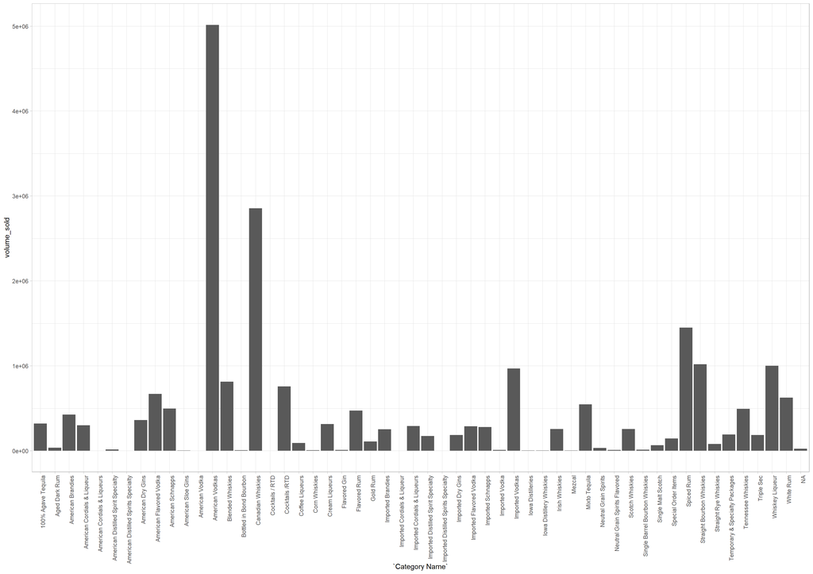

```r
data %>%
  group_by(`Category Name`) %>%
  summarise(volume_sold = sum(`Volume Sold (Liters)`)) %>%
   ggplot(aes(x = `Category Name`, y = volume_sold )) +
    geom_col() +
    theme(axis.text.x = element_text(angle = 90, hjust = 1))
```

```r
#tbl_df(table(data$`Category Name`))
```

# Question 5

#### clean the city data

```r
count(data, City)
```

```
## # A tibble: 414 x 2
##    City            n
##    <chr>       <int>
##  1 Ackley        862
##  2 Adair         444
##  3 Adel         2851
##  4 Afton         262
##  5 Akron         492
##  6 Albert City    63
##  7 Albia        2671
##  8 Albion        140
##  9 Alburnett     169
## 10 Alden         919
## # ... with 404 more rows
```

```r
data$City[data$City == "AMES"] <- "Ames"
count(data, City)
```

```
## # A tibble: 414 x 2
##    City            n
##    <chr>       <int>
##  1 Ackley        862
##  2 Adair         444
##  3 Adel         2851
##  4 Afton         262
##  5 Akron         492
##  6 Albert City    63
##  7 Albia        2671
##  8 Albion        140
##  9 Alburnett     169
## 10 Alden         919
## # ... with 404 more rows
```

```r
df <- dat %>% filter(year==2018) %>% select(day, month, `Volume Sold (Liters)`, `Sale (Dollars)`)
summary(df)
```

```
##      day               month           Volume Sold (Liters)
##  Length:2355558     Length:2355558     Min.   :   0.020
##  Class :character   Class :character   1st Qu.:   1.500
##  Mode  :character   Mode  :character   Median :   4.800
##                                        Mean   :   9.295
##                                        3rd Qu.:  10.500
##                                        Max.   :8964.000
##  Sale (Dollars)
##  Min.   :     0.0
##  1st Qu.:    31.5
##  Median :    72.0
##  Mean   :   141.9
##  3rd Qu.:   141.8
##  Max.   :279557.3
```

```r
plt <- ggplot(df, aes(x=day, y=`Volume Sold (Liters)`)) + geom_point() + facet_wrap(~month)
#ggplotly()
```

#### ISU home football fall dates

```r
#isu_fall2 <- data_frame(Date = c("2017-9-2", "2017-9-9", "2017-9-28",
  #                                "2017-10-14", "2017-10-28", "2017-11-11"))
# isu_fall <- isu_fall %>% mutate(Date = lubridate::ymd(Date))

isu_fall <- data_frame(Year = c(rep(2017, 6)),
                       Month = c(9, 9, 9, 10, 10, 11),
                       Day = c(2, 9, 28, 14, 28, 11))
isu_fall
```

```
## # A tibble: 6 x 3
##    Year Month   Day
##   <dbl> <dbl> <dbl>
## 1  2017     9     2
## 2  2017     9     9
## 3  2017     9    28
## 4  2017    10    14
## 5  2017    10    28
## 6  2017    11    11
```

Note: your submission is supposed to be fully reproducible, i.e. the TA and I will ‘knit’ your submission in RStudio.

For the submission: submit your solution in an R Markdown file and (just for insurance) submit the corresponding html (or Word) file with it.